# Final Project A Deepdive on Regork Campaigns

2022-10-06

## Improvement of Sales Through Overall Campaign Performance

- Regork ran multiple campaigns in the year 2017 to boost sales and increase revenue.
- The goal of the case-study is to analyze the campaigns and suggest improvements to enhance the total sales.
- In order to do this, we analyzed the campaign performance based on the redemption rates, total sales generated by the products (which were part of the campaign), households targeted, ages and income ranges of the customers.
- We utilized the completejourney dataset to identify trends and patterns in the data and generated insights to help the leadership make effective data-driven decisions.
- Throughout the analysis, we identify the best-case practices and patterns in certain campaigns and suggest areas of improvement to simulate the poorer performing campaigns.

```r
# Required data frames from the completejourney dataset
transactions_df <- get_transactions()
promotions_df <- get_promotions()
products_df <- products

campaigns_df <- campaigns %>%
  transform(campaign_id = as.numeric(campaign_id))

coupons_df <- coupons %>%
  transform(campaign_id = as.numeric(campaign_id))

campaign_descriptions_df <- campaign_descriptions %>%
  transform(campaign_id = as.numeric(campaign_id))
```

```r
camp_prod_tsv <- coupons_df %>%
  select(campaign_id, product_id) %>%
  inner_join(campaign_descriptions_df, by = "campaign_id") %>%
  select(campaign_id, product_id, campaign_type) %>%
  inner_join(transactions_df, by = "product_id") %>%
  mutate(transaction_month = lubridate::month(transaction_timestamp, label = TRUE)
         , month_num = lubridate::month(transaction_timestamp))%>%
  select(campaign_type, campaign_id, product_id, transaction_month, month_num, sales_value) %>%
  group_by(campaign_id, campaign_type, month_num, transaction_month) %>%
  summarise(total_sales = sum(sales_value)) %>%
  arrange(campaign_type, campaign_id)
```

[output not shown]

```r
#Households Targeted per campaign
camp_hh_targeted <- campaigns %>%
  group_by(campaign_id) %>%
  summarise(hh_targeted = n_distinct(household_id)) %>%
  arrange(campaign_id) %>%
  inner_join(campaign_descriptions, by = "campaign_id") %>%
  transform(campaign_id = as.numeric(campaign_id)) %>%
  select(campaign_type, campaign_id, hh_targeted) %>%
  group_by(campaign_type)

camp_hh_redeemed <- campaigns %>%
  select(campaign_id) %>%
  distinct() %>%
  left_join(coupon_redemptions, by = c("campaign_id")) %>%
  group_by(campaign_id) %>%
  summarise(hh_redeemed = n_distinct(household_id)) %>%
  arrange(campaign_id) %>%
  inner_join(campaign_descriptions, by = "campaign_id") %>%
  transform(campaign_id = as.numeric(campaign_id)) %>%
  select(campaign_id, campaign_type, hh_redeemed)
```

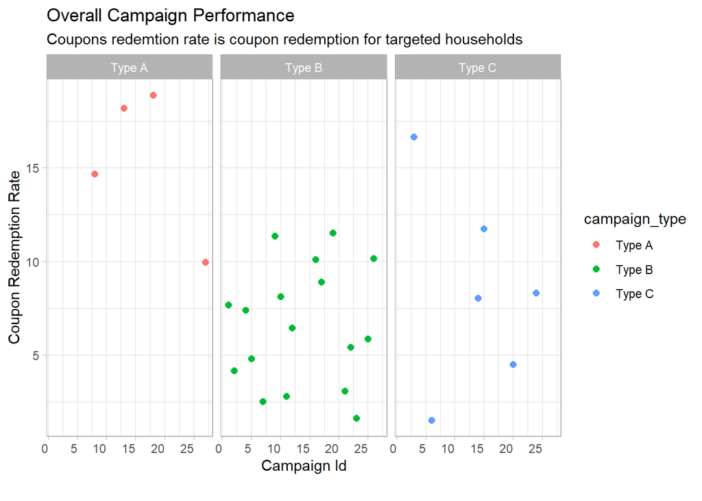

```r
camp_perf_df <- camp_hh_targeted %>%
  inner_join(camp_hh_redeemed, by = "campaign_id") %>%
  arrange(campaign_id) %>%
  mutate(redemption_rate = (hh_redeemed/hh_targeted)*100) %>%
  rename(campaign_type = campaign_type.x) %>%
  select(campaign_id, campaign_type, hh_targeted, hh_redeemed, redemption_rate) %>%
  arrange(desc(redemption_rate))

max_camp_df <- campaigns %>%
  select(campaign_id) %>%
  transform(campaign_id = as.numeric(campaign_id)) %>%
  summarise(cnt = max(campaign_id))
maximum_campaign_id <- max_camp_df$cnt

overall_camp_perf <- camp_perf_df %>%
  ggplot(aes(y =redemption_rate, x = campaign_id, color = campaign_type)) +
  geom_point(size =2) +
  scale_color_manual(values = c('#F8766E',
                                '#00BA38',
                                '#619CFF'))+
  scale_x_continuous(breaks = seq(0,maximum_campaign_id+1,5)) +
  facet_wrap(~ campaign_type) +
  ylab('Coupon Redemption Rate') +
  xlab('Campaign Id') +
  labs(
    title = "Overall Campaign Performance",
    subtitle = "Coupons redemtion rate is coupon redemption for targeted households",
    caption = "") +
  theme_light()+
  theme(axis.text.x = element_text(angle=0, vjust=1, hjust=1))
overall_camp_perf
```

The plot above shows the overall performance of the campaigns based on the total redemption rates of the campaigns.

Clearly, Type A campaigns are performing better than the rest of the campaigns.

## Type B Campaign Activity vs Sales Generated

From the previous observations we see that Type B has multiple active campaigns, but the redemption rate is less when compared to Type A which has few campaigns

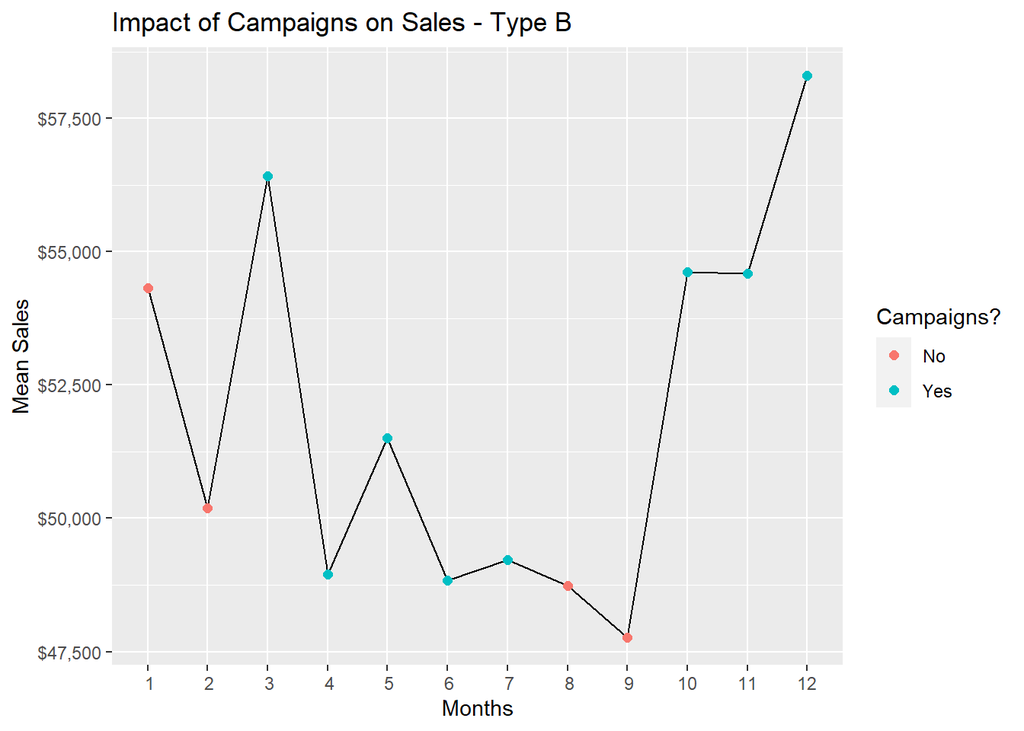

```r
# Type B Campaign Activity vs Sales Generated

campaign_months <-c(3,4,5,6,7,10,11,12)
type_b_sales <-campaign_descriptions %>%
  inner_join(coupons, by="campaign_id") %>%
  filter(campaign_type== 'Type B') %>%
  inner_join(transactions_df, by="product_id") %>%
  mutate(month=month(transaction_timestamp),
         Camp_there =case_when(
           month %in% campaign_months ~ "Yes",
           TRUE ~ "No")) %>%
  group_by(month,Camp_there)%>%
  summarize(sum= sum(sales_value))
type_b_sales %>%
  ggplot()+
  geom_line(aes(x=month, y=sum))+
  geom_point(aes(x=month, y=sum, group = Camp_there,color= Camp_there),size=2)+
  scale_y_continuous(labels=scales::dollar_format())+
  xlab("Months") +
  ylab("Mean Sales") +
  labs(title= "Impact of Campaigns on Sales - Type B")+
  scale_x_discrete(limits = c(1:12)) +
  guides(col=guide_legend("Campaigns?"))
```

**Proposed Solution:**

- To launch campaigns in the months where the sales are the lowest in order to maintain average sales.
- We can have multiple campaigns in November as it is holiday season (Currently there is just one in November whereas there are five in December)

## Impact Of Campaign Duration On Redemption Rate

```r
campaign_duration_rr <- campaign_descriptions %>%
  transform(campaign_id=as.numeric(campaign_id)) %>%
  inner_join(camp_perf_df, by= "campaign_id")%>%
  mutate(
    campaign_duration = end_date - start_date,
    campaign_duration = case_when(
      campaign_duration %in% 30:40 ~ "30 to 40",
      campaign_duration %in% 41:50 ~ "40 to 50",
      campaign_duration %in% 51:60 ~ "50 to 60",
      campaign_duration %in% 51:161 ~ "Over 60")) %>%
  group_by(campaign_duration)%>%
  summarise(mean_pf=mean(redemption_rate))
print(campaign_duration_rr)
```

```
## # A tibble: 4 × 2
##   campaign_duration mean_pf
##   <chr>               <dbl>
## 1 30 to 40             6.32
## 2 40 to 50            11.4
## 3 50 to 60            15.2
## 4 Over 60              7.70
```

The table above summarizes the Campaign Duration and the corresponding Mean Redemption Rate

Our analyses shows that the redemption rate is maximum when the campaign runs between 51 to 60 days.

The campaign isn’t very efficient when its run between 30 to 40 days or over two months.

**Proposed Solution:**

In order to attain Maximum redemption Rate, we should run the campaign in the range of 41 to 60 days.

### Coupon Redemption Of Household – By Income Range

The graph below shows income wise split for the households who redeemed the promotional benefits at least once versus the households who have not redeemed the coupons.

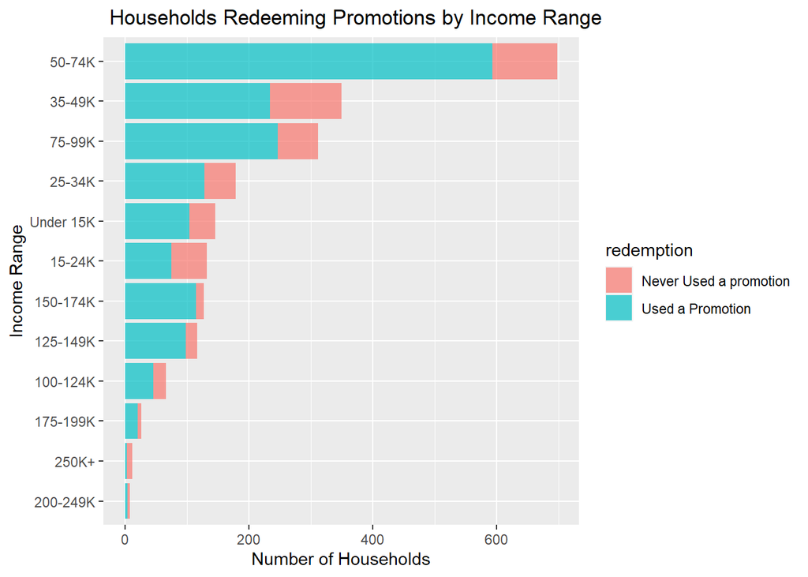

```r
# Coupon Redemption Of Household – By Income Range

demo_income <-demographics %>%
  left_join(coupon_redemptions, by="household_id")%>%
  mutate(redemption= case_when(
    is.na(redemption_date) ~ 'Never Used a promotion',
    TRUE ~'Used a Promotion'
  )) %>%
  select(age,income,redemption) %>%
  group_by(income,redemption)%>%
  summarize(hh_count=n())

demo_income_plot <- demo_income %>%
  ggplot(aes(reorder(income, hh_count),hh_count, fill=redemption)) +
  geom_bar(position="stack", space = 1,stat="identity", alpha=0.7) +
  #scale_x_discrete(guide = guide_axis(n.dodge=2))+
  coord_flip()+
  xlab("Income Range") +
  ylab("Number of Households")           +
  guides(col=guide_legend("Coupon Redemption?"))           +
  labs(title= " Households Redeeming Promotions by Income Range")

demo_income_plot
```

**Proposed Solution:**

Households with a family income of 100K and above have been least targeted by campaigns. As they are high income generating households, there is a good Probability that focused campaigns on these income ranges can boost the overall Sales.

## Coupon Redemptions Of Household – By Age

```r
# Coupon Redemption Of Household – By Age

demo_age <-demographics %>%
  left_join(coupon_redemptions, by="household_id")%>%
  mutate(redemption= case_when(
    is.na(redemption_date) ~ 'Never Used a promotion',
    TRUE ~'Used a Promotion'
  )) %>%
  select(age,income,redemption) %>%
  group_by(age,redemption)%>%
  summarize(hh_count=n())
```

[output not shown]

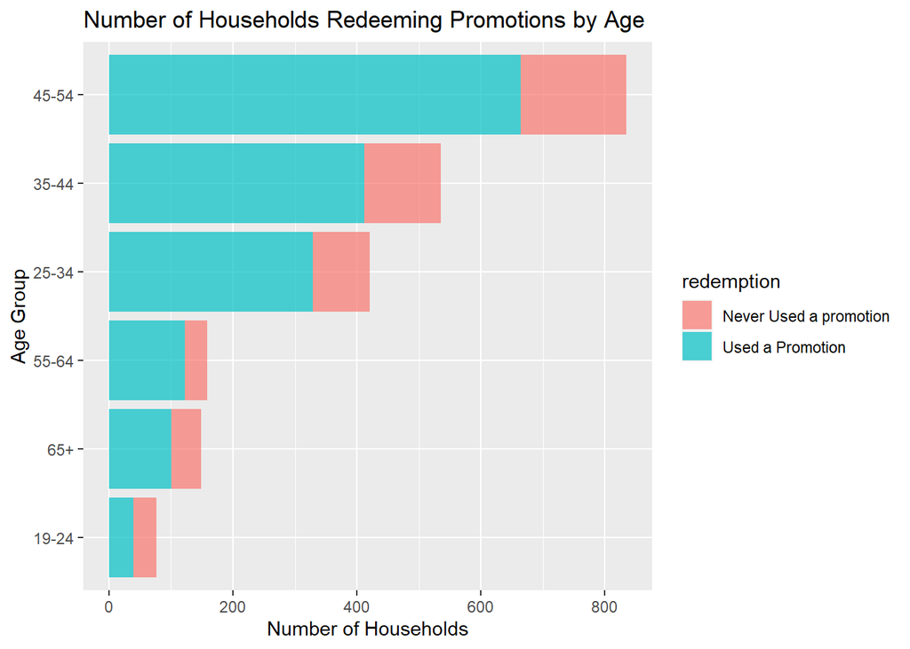

```r
demo_age %>%
  ggplot(aes(reorder(age,hh_count),hh_count,fill=redemption)) +
  geom_bar(position="stack", stat="identity",alpha=0.7) +
  coord_flip()           +
  xlab("Age Group") +
  ylab("Number of Households")           +
  guides(col=guide_legend("Coupon Redemption?"))           +
  labs(title= "Number of Households Redeeming Promotions by Age")
```

The graph above shows age wise split for the households who have redeemed the promotional benefits at least once versus the households who have not redeemed the coupons.

Age group between the period of 45-54 has the highest number of campaign promotional redemption users followed by the age group 35-44.

**Proposed Solution:**

Young adults in the age group of 19-24 and older citizens above age 55 have been least targeted by campaigns and have the least promotional benefit users. This represents an opportunity to specifically direct efforts to launch campaigns for these age groups.

## Trend of Total Sales for Type A Campaign Duration

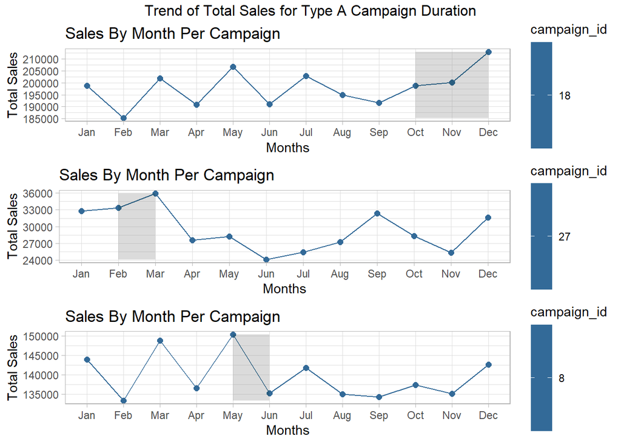

```r
# Campaign total sales value info with start date and end date

camp_info_df <- campaign_descriptions_df %>%
  select(campaign_id, campaign_type, start_date, end_date) %>%
  mutate(start_month = lubridate::month(start_date), end_month = lubridate::month(end_date)
         , start_month_nm = lubridate::month(start_date, label = TRUE),
         end_month_nm = lubridate::month(end_date, label = TRUE))

camp_prod_tsv <- camp_prod_tsv %>%
  inner_join(camp_info_df, by = c("campaign_id","campaign_type")) %>%
  select(campaign_id, campaign_type, transaction_month, total_sales, start_month, end_month, start_month_nm,
         end_month_nm, month_num)

# minimum and maximum total sales value for campaigns

min_max_sales <- camp_prod_tsv %>%
  group_by(campaign_id) %>%
  summarize(max_sales = max(total_sales), min_sales = min(total_sales))

camp_prod_tsv <- camp_prod_tsv %>%
  inner_join(min_max_sales, by = "campaign_id")

# Type - A campaigns trend wrt total sales value between start and end date

type_a_campaigns <- campaign_descriptions %>% filter(campaign_type == "Type A") %>% select(campaign_id)

for(i in type_a_campaigns$campaign_id){
p <-camp_prod_tsv %>%
    filter(campaign_id == i) %>%
    ggplot() +
    geom_line(aes(transaction_month, total_sales, group = campaign_id, colour = campaign_id)) +
    geom_point(aes(transaction_month, total_sales, group = campaign_id, colour = campaign_id),size = 2) +
    #geom_point(aes(transaction_month, camp_month),size = 5) +
    # geom_line(aes(transaction_month, camp_month)) +
    geom_rect(aes(NULL, NULL, xmin = start_month_nm, xmax = end_month_nm, ymin = min_sales, ymax = max_sales), fill = factor(1), alpha = 0.01) +
    theme_light() +
    theme(legend.position = 'right') +
    labs(title = "Sales By Month Per Campaign",
         x = "Months",
         y = "Total Sales"
    )
new_name <- paste0("plot_",i)
assign(new_name, p)
rm(p)
}

grid.arrange(plot_18, plot_27, plot_8, layout_matrix = rbind(c(1),c(2), c(3)), top="Trend of Total Sales for Type A Campaign Duration")
```

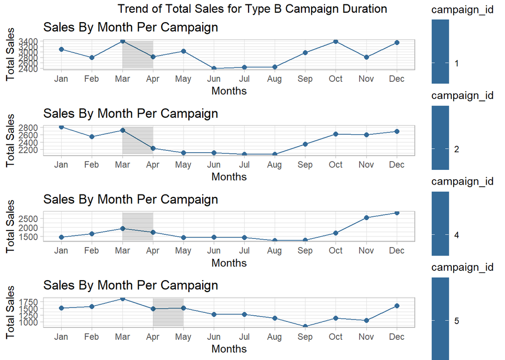

```r
# Type - B campaigns trend wrt total sales value between start and end date

type_b_campaigns <- campaign_descriptions_df %>% filter(campaign_type == "Type B") %>% filter(start_date > '2017-01-01' & end_date <= '2017-12-31') %>% select(campaign_id)

for(i in type_b_campaigns$campaign_id){
  p <-camp_prod_tsv %>%
    filter(campaign_id == i) %>%
    ggplot() +
    geom_line(aes(transaction_month, total_sales, group = campaign_id, colour = campaign_id)) +
    geom_point(aes(transaction_month, total_sales, group = campaign_id, colour = campaign_id),size = 2) +
    #geom_point(aes(transaction_month, camp_month),size = 5) +
    # geom_line(aes(transaction_month, camp_month)) +
    geom_rect(aes(NULL, NULL, xmin = start_month_nm, xmax = end_month_nm, ymin = min_sales, ymax = max_sales), fill = factor(1), alpha = 0.01) +
    theme_light() +
    theme(legend.position = 'right') +
    labs(title = "Sales By Month Per Campaign",
         x = "Months",
         y = "Total Sales"
    )
  new_name <- paste0("plot_typeb_",i)
  assign(new_name, p)
  rm(p)
}

grid.arrange(plot_typeb_1, plot_typeb_2, plot_typeb_4, plot_typeb_5, layout_matrix = rbind(c(1),c(2),c(3), c(4)), top="Trend of Total Sales for Type B Campaign Duration")
```

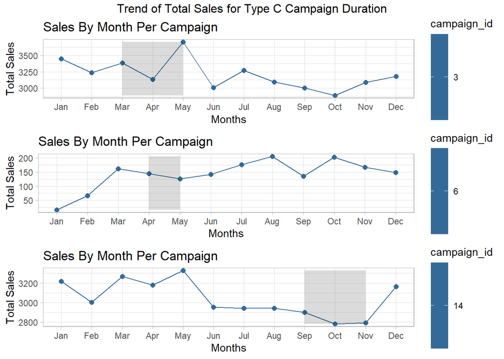

```r
# Type - C campaigns trend wrt total sales value between start and end date

type_c_campaigns <- campaign_descriptions_df %>% filter(campaign_type == "Type C") %>% filter(start_date > '2017-01-01' & end_date <= '2017-12-31') %>% select(campaign_id)

for(i in type_c_campaigns$campaign_id){
  p <-camp_prod_tsv %>%
    filter(campaign_id == i) %>%
    ggplot() +
    geom_line(aes(transaction_month, total_sales, group = campaign_id, colour = campaign_id)) +
    geom_point(aes(transaction_month, total_sales, group = campaign_id, colour = campaign_id),size = 2) +
    #geom_point(aes(transaction_month, camp_month),size = 5) +
    # geom_line(aes(transaction_month, camp_month)) +
    geom_rect(aes(NULL, NULL, xmin = start_month_nm, xmax = end_month_nm, ymin = min_sales, ymax = max_sales), fill = factor(1), alpha = 0.01) +
    theme_light() +
    theme(legend.position = 'right') +
    labs(title = "Sales By Month Per Campaign",
         x = "Months",
         y = "Total Sales"
    )
  new_name <- paste0("plot_typec_",i)
  assign(new_name, p)
  rm(p)
}

grid.arrange(plot_typec_3, plot_typec_6, plot_typec_14,
             layout_matrix = rbind(c(1), c(2), c(3)), top="Trend of Total Sales for Type C Campaign Duration")
```

The best-case practice from Type - A, can be implemented by Type B and C to boost their sales and improve revenue.

## Limitations

- Coupon related sales information is not reflected in the transaction dataset. Hence the analysis was made for the total sales of the products targeted by the campaigns.
- We have transaction data only for 2017 whereas campaign data is present from 2016 - 2018. Hence the analysis was limited to 2017. There is no granular information about the characteristics and other attributes about campaigns and coupon.
- This limits our ability to analyze and give precise predictions of the type of campaigns and coupons.